# Data Science for Bioinformatics - Week 07

# Mammals dataset

We first load the dataset into a variable we call “mammals”

```r
library(tidyverse)

mammals <- read_csv(file = "../datasets/dataset.01.rsbl20150010supp1.csv")
```

#### Q: Visualize the distribution of GC content (GC3) for X chromosome genes and autosomal genes for each species

```r
mammals %>% group_by(chrMark) %>% summarise(n = n())
```

```
## # A tibble: 2 x 2
##   chrMark     n
##   <chr>   <int>
## 1 A       16945
## 2 X         382
```

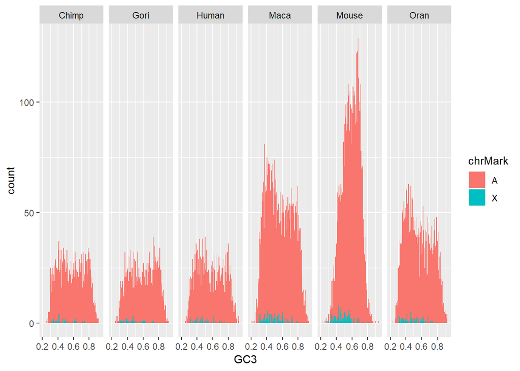

```r
ggplot(mammals, aes(x = GC3, fill = chrMark)) + geom_histogram(bins = 100) + facet_grid(~Species)
```

#### Q: Test if the GC content (GC3) is the same for X chromosomal genes and autosomal genes (not X) for each species

```r
mammals %>%
  group_by(Species) %>%
  summarise(
    meanX = mean(GC3[chrMark == 'X']),
    meanA = mean(GC3[chrMark == 'A']),
    p_value = t.test(x = GC3[chrMark == 'X'], y = GC3[chrMark == 'A'])$p.value)
```

```
## # A tibble: 6 x 4
##   Species meanX meanA  p_value
##   <chr>   <dbl> <dbl>    <dbl>
## 1 Chimp   0.480 0.581 2.53e- 5
## 2 Gori    0.474 0.596 4.31e- 7
## 3 Human   0.476 0.578 3.55e- 6
## 4 Maca    0.491 0.567 1.25e- 8
## 5 Mouse   0.479 0.591 3.59e-21
## 6 Oran    0.492 0.566 1.42e- 6
```

A: It is not the same. Given the p values, we can reject the null hypothesis that the X genes have the same distribution as autosome genes.

#### Q: Test if the GC content (GC3) is the same for autosomal genes (not X) in humans and chimpanzee?

```r
mammals %>%
  filter((Species == 'Human' | Species == 'Chimp') &  chrMark == 'A') %>%
  summarise(
    mean_humans = mean(GC3[Species == 'Human']),
    mean_chimps = mean(GC3[Species == 'Chimp']),
    p_value = t.test(x = GC3[Species == 'Human'], y = GC3[Species == 'Chimp'])$p.value)
```

```
## # A tibble: 1 x 3
##   mean_humans mean_chimps p_value
##         <dbl>       <dbl>   <dbl>
## 1       0.578       0.581   0.556
```

A: The GC3 content seems to be similar in humans and chimps. The obtained p value is high enough for us to accept the null hypothesis. This also makes sense given the GC3 distributions we have seen before.

#### Q: Test if the GC content (GC3) is the same for autosomal genes (not X) in humans and gorilla?

```r
mammals %>%
  filter((Species == 'Human' | Species == 'Gori') &  chrMark == 'A') %>%
  summarise(
    mean_humans = mean(GC3[Species == 'Human']),
    mean_gori = mean(GC3[Species == 'Gori']),
    p_value = t.test(x = GC3[Species == 'Human'], y = GC3[Species == 'Gori'])$p.value)
```

```
## # A tibble: 1 x 3
##   mean_humans mean_gori  p_value
##         <dbl>     <dbl>    <dbl>
## 1       0.578     0.596 0.000876
```

A: No. The null hypothesis is rejected in this case.